# DESeq IC50: Ovarian Cancer Cell Line RNAseq Platinum Sensitivity

```r
library(knitr)
knit("src/load_inputs.Rmd")
```

```
processing file: src/load_inputs.Rmd
```

[output not shown]

|  | files | CellLine | PlatinumSensitivity | Subtype | IC50 | scaled_IC50 |
| --- | --- | --- | --- | --- | --- | --- |
| X14 | X14 | CAOV3 | sensitive | HGSC | 3.93 | -0.9213739 |
| X22 | X22 | CAOV4 | resistant | HGSC | 14.53 | 1.1683692 |
| X21 | X21 | COV362 | resistant | HGSC | 14.40 | 1.1427403 |
| X31 | X31 | JHOS-2 | resistant | HGSC | 17.07 | 1.6691190 |
| X30 | X30 | JHOS-4 | sensitive | HGSC | 3.81 | -0.9450314 |
| X17 | X17 | KURAMOCHI | intermediate | HGSC | 7.20 | -0.2767079 |

```
  |.................................................                     |  70%
  |........................................................              |  80% [read count matrix]
  |...............................................................       |  90%
  |......................................................................| 100% [unnamed-chunk-6]
```

```
output file: load_inputs.md
```

```
[1] "load_inputs.md"
```

## Run DESeq using IC50 as continuous variable

### Create DESeqDataSet object dds

DEseq with a continuous covariate assumes that counts are proportional to 2^(a * x) where a is the log2FoldChange and x is the covariate

```r
metadata$scaled_IC50 = scale(metadata$IC50, center = TRUE) # centering and scaling improves GLM convergence
dds2 <- DESeqDataSetFromMatrix(countData = countmatrix2, colData = metadata, design = ~ scaled_IC50)
```

### Run DESeq2

```r
path = paste0(deseq_Rdata_folder,
              "/dds_HGSC_IC50.Rdata")

dds2 <- DESeq(dds2)
save(dds2, file = path)

# Alternatively, load the dds2 object
load(path)
```

### Print DESeq results

The fold change of a covariate is the change per unit increase/decrease

```r
res2 <- results(dds2)
res2
```

```
log2 fold change (MLE): scaled IC50
Wald test p-value: scaled IC50
DataFrame with 29744 rows and 6 columns
            baseMean log2FoldChange     lfcSE       stat      pvalue      padj
           <numeric>      <numeric> <numeric>  <numeric>   <numeric> <numeric>
A1BG      22.4540264     -0.1215529  0.403464 -0.3012729 0.763206394 0.9685697
A1BG-AS1  48.3012543     -0.0566146  0.332661 -0.1701874 0.864862738 0.9846166
A1CF       0.0619977     -0.1389183  1.600522 -0.0867956 0.930833963        NA
A2M      825.3555009     -3.8216781  1.054950 -3.6226136 0.000291641 0.0533006
A2M-AS1   32.1155303      1.1634974  0.340433  3.4176990 0.000631529 0.0854247
...              ...            ...       ...        ...         ...       ...
ZYG11A       544.635     -0.1058247  0.184023  -0.575062    0.565249  0.930792
ZYG11B      2015.753     -0.2470281  0.203243  -1.215431    0.224202  0.815350
ZYX         4542.791     -0.0335395  0.218579  -0.153443    0.878049  0.985452
ZZEF1       1668.988      0.1737199  0.193146   0.899421    0.368429  0.877233
ZZZ3        3769.727     -0.0141947  0.122524  -0.115853    0.907769  0.988464
```

```r
path = paste0(deseq_output_folder,
              "/DESeq_HGSC_IC50.csv")
write.csv(as.data.frame(res2), file = path)
```

### Filter DESeq2 results for significant genes

Filter res for padj < 0.05 and |log2FC| >= 1.2

```r
res.2.filtered <- as.data.frame(res2) %>%
  filter(padj<0.05)%>%
  filter(log2FoldChange >= 1.2 | log2FoldChange <= -1.2)
res.2.filtered
```

|  | baseMean | log2FoldChange | lfcSE | stat | pvalue | padj |
| --- | --- | --- | --- | --- | --- | --- |
| ACTG2 | 4.997616e+02 | -4.413745 | 1.1390054 | -3.875087 | 1.065865e-04 | 2.919734e-02 |
| ART5 | 1.308302e+01 | -2.703574 | 0.7209482 | -3.750026 | 1.768163e-04 | 4.032572e-02 |
| CABP4 | 1.244723e+01 | 3.642398 | 0.9935380 | 3.666088 | 2.462893e-04 | 4.871891e-02 |
| CAPN9 | 4.549569e+01 | -2.741719 | 0.7140844 | -3.839489 | 1.232907e-04 | 3.239079e-02 |
| CCDC129 | 6.930186e+02 | 7.006557 | 1.5422492 | 4.543077 | 5.543897e-06 | 3.536300e-03 |
| CCDC3 | 4.666491e+02 | -1.524185 | 0.3990971 | -3.819084 | 1.339480e-04 | 3.303773e-02 |
| CCL5 | 2.138581e+02 | 3.176418 | 0.6737194 | 4.714748 | 2.420097e-06 | 1.769196e-03 |
| CDH22 | 2.480485e+01 | 4.546000 | 1.0521120 | 4.320833 | 1.554414e-05 | 7.467405e-03 |
| CILP | 2.582634e+02 | -2.894174 | 0.7719671 | -3.749090 | 1.774773e-04 | 4.032572e-02 |
| COLEC10 | 4.626710e+02 | 4.037020 | 0.7488219 | 5.391162 | 7.000359e-08 | 7.356503e-05 |

[output cut: 69 more lines]

## Data QC

No need to redo data transformation and PCA plot because this is the same as the previous section using categories instead of IC50.

### Data transformation

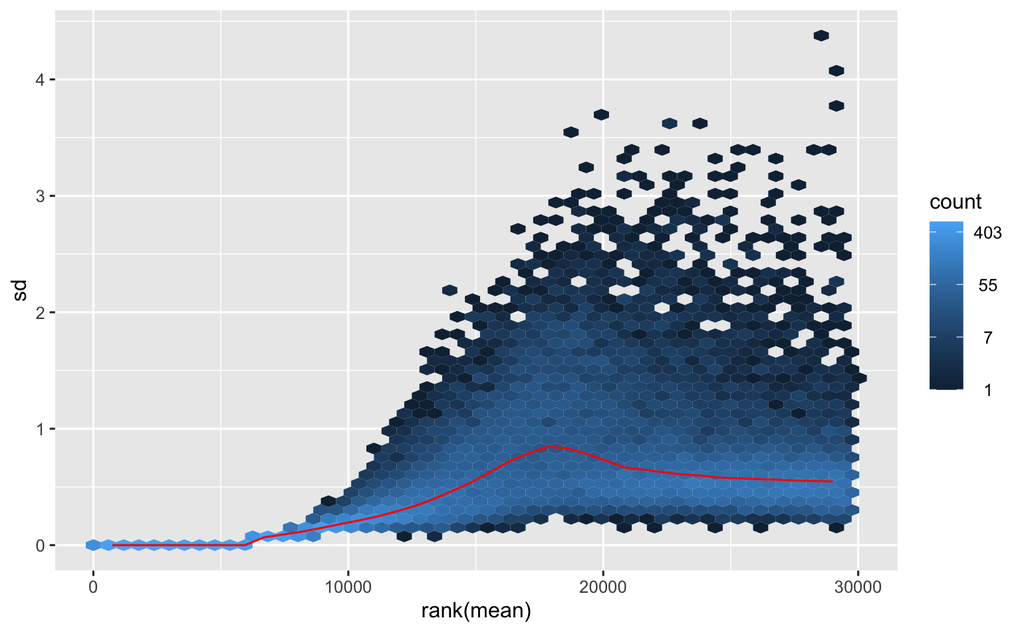

```r
vsd2 <- vst(dds2)
meanSdPlot(assay(vsd2))
```

## Data visualization

### Plot Heatmap of top differentially expressed genes

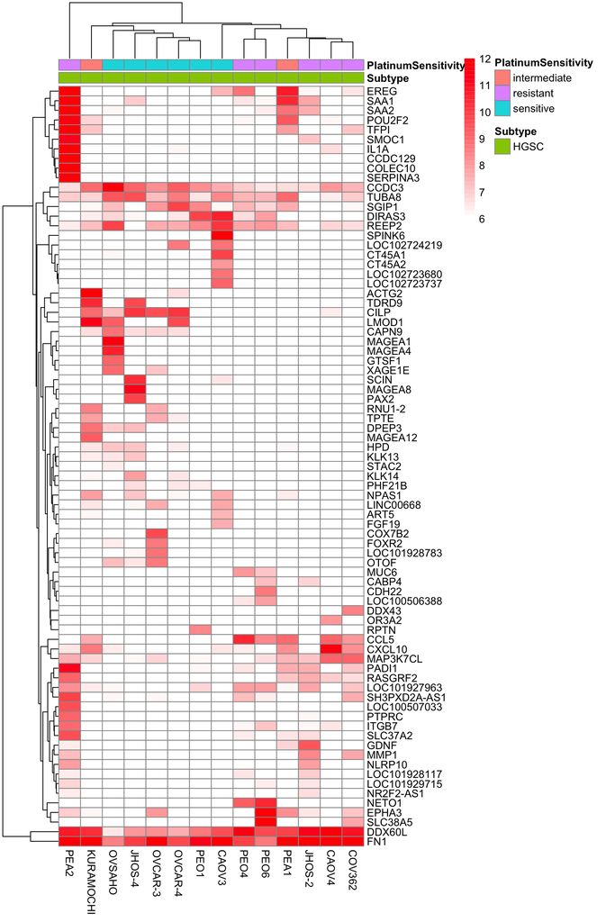

```r
vsd2.df <-as.data.frame(assay(vsd2))
color <- colorRampPalette(c("white", "red"))(40)
breaks <- seq(6,12,length.out=40)
pheatmap(vsd2.df[rownames(res.2.filtered),], labels_col=colData(dds2)[,c("CellLine")],annotation_col=df, color=color, breaks=breaks)
```

### Heatmap with mean-centered data

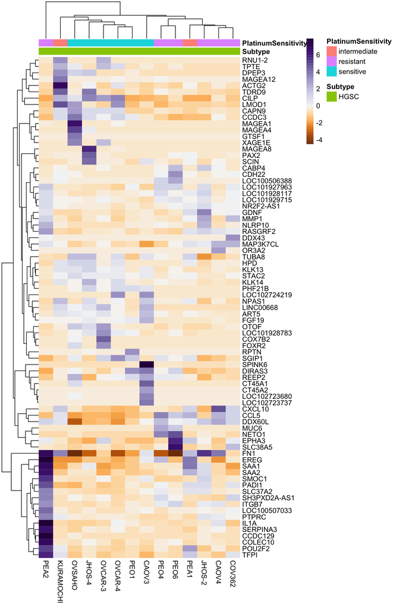

```r
vsd2.meancenter <- apply(vsd2.df, 1, center_scale)
vsd2.meancenter <-t(vsd2.meancenter)
colnames(vsd2.meancenter) <- colnames(vsd2.df)
vsd2.meancenter <- as.data.frame(vsd2.meancenter)
color <- colorRampPalette(brewer.pal(11, "PuOr"))(50)
myBreaks2 <- c(seq(min(vsd2.meancenter[rownames(res.2.filtered),]), 0, length.out=ceiling(50/2) + 1),
              seq(max(vsd2.meancenter[rownames(res.2.filtered),])/50, max(vsd2.meancenter[rownames(res.2.filtered),]), length.out=floor(50/2)))
pheatmap(vsd2.meancenter[rownames(res.2.filtered),], labels_col=colData(dds)[,c("CellLine")], color=color, border_color = NA, annotation_col = df, breaks=myBreaks2)
```

### Volcano Plots

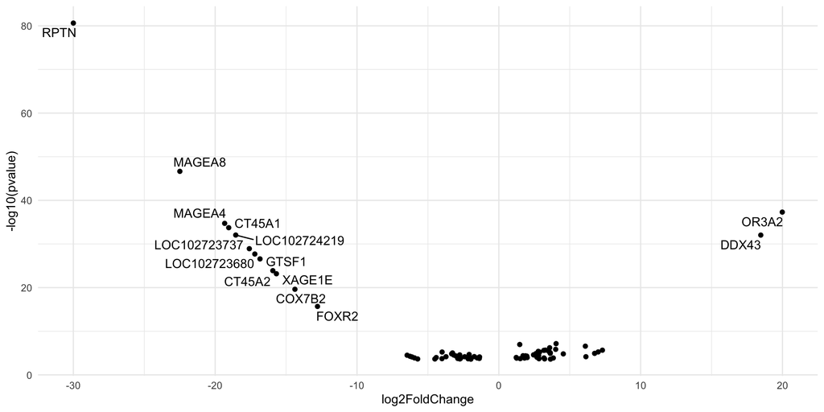

```r
res.2.filtered %>%
  ggplot(aes(x=log2FoldChange, y=-log10(pvalue), label=rownames(res.2.filtered))) +
  geom_point() +
  theme_minimal() +
  scale_color_manual(values = c("black", "blue", "red"))+
  geom_text_repel()
```

## Gene ontology

### GSEA of genes differentially expressed based on IC50 of cellline

Perform gene set enrichment analysis using Cluster Profiler. This gives us GO pathways that are significantly regulated based on the log2fold change of expression of individual genes.

Using a padj Cutoff of 0.15.

```r
gene_list2 <- res2$log2FoldChange
names(gene_list2) = rownames(res2)
gene_list2 <- sort(gene_list2, decreasing = TRUE)

# Set the seed so our results are reproducible:
set.seed(2024)
gsea_res2 <- gseGO(gene_list2, ont = "BP", OrgDb = "org.Hs.eg.db", keyType = "SYMBOL", seed = TRUE, pvalueCutoff = .15)
```

```
preparing geneSet collections...
GSEA analysis...
Warning: There are ties in the preranked stats (7.97% of the list).
The order of those tied genes will be arbitrary, which may produce unexpected results.leading edge analysis...
done...
```

```r
# Format output
gsea_res_df2 <- as.data.frame(gsea_res2)
gsea_res_df2 <- gsea_res_df2 %>%
  mutate(original_row_num = row_number())
gsea_res_df2 <- gsea_res_df2[order(gsea_res_df2$NES, decreasing = TRUE),]
row.names(gsea_res_df2) <- gsea_res_df2$ID
```

NES is the normalized enrichment score.

```r
gsea_res_df_short2 <- gsea_res_df2[c("pvalue", "p.adjust", "NES", "Description")]
gsea_res_df_short2$"core_enrichment_genes" <- gsea_res_df2$core_enrichment
```

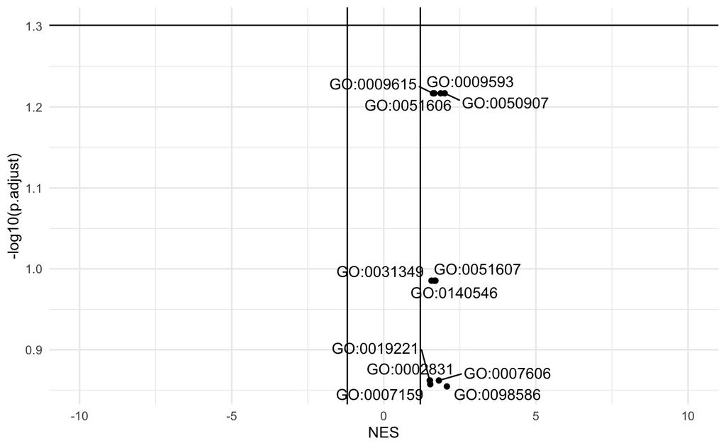

```r
as.data.frame(gsea_res_df_short2) %>%
  ggplot(aes(x = NES, y = -log10(p.adjust), label = rownames(gsea_res_df_short2))) +
  geom_point() +
  theme_minimal() +
  scale_color_manual(values = c("black", "blue", "red")) +
  geom_text_repel() +
  geom_hline(yintercept = 1.301) +
  geom_vline(xintercept = 1.2) +
  geom_vline(xintercept = -1.2) +
  xlim(-10, 10)
```

#### Upregulated pathways

```r
gsea_res_df_short.up2 <- subset(gsea_res_df_short2, gsea_res_df_short2$NES >= 0)
gsea_res_df_short.up2 = gsea_res_df_short.up2[order(gsea_res_df_short.up2$p.adjust), ]
path = paste0(deseq_output_folder,
              "/IC50_cisplatin_resistant_significantly_upregulated_pathways.csv")
write.csv(gsea_res_df_short.up2, file = path)
gsea_res_df_short.up2
```

|  | pvalue | p.adjust | NES | Description | core_enrichment_genes |
| --- | --- | --- | --- | --- | --- |
| GO:0050907 | 3.146131e-05 | 0.0606848 | 2.001854 | detection of chemical stimulus involved in sensory perception | OR3A2/CST2/PIGR/AZGP1/OR3A1/OR10AD1/OR4C6/PIP/TAS2R43/OR1Q1/…… |
| GO:0009593 | 3.848620e-05 | 0.0606848 | 1.867480 | detection of chemical stimulus | OR3A2/CST2/PIGR/AZGP1/OR3A1/C4B/OR10AD1/OR4C6/PIP/TAS2R43/SS…… |
| GO:0051606 | 3.905699e-05 | 0.0606848 | 1.660922 | detection of stimulus | OR3A2/CABP4/CST2/PIGR/AZGP1/OR3A1/NGFR/C4B/OR10AD1/OR4C6/PIP…… |
| GO:0009615 | 3.125169e-05 | 0.0606848 | 1.614754 | response to virus | IL1B/CCL5/PTPRC/POU2F2/CXCL10/IFNL1/MMP12/IFNB1/CCL4/DDX60L/…… |
| GO:0051607 | 1.164750e-04 | 0.1034132 | 1.698345 | defense response to virus | IL1B/PTPRC/CXCL10/IFNL1/MMP12/IFNB1/DDX60L/TRIM22/OAS2/IFNL2…… |
| GO:0140546 | 1.099762e-04 | 0.1034132 | 1.665775 | defense response to symbiont | IL1B/PTPRC/CXCL10/IFNL1/MMP12/IFNB1/DDX60L/TRIM22/OAS2/IFNL2…… |
| GO:0031349 | 1.092431e-04 | 0.1034132 | 1.567214 | positive regulation of defense response | COLEC10/IL1B/EREG/NLRP10/CCL5/LGALS2/LTA/FCRL3/MMP12/PLA2G7/IFNB1/S100A8/TNFSF18/MMRN2/RSAD2/PAK3/TXK/SH2D1B/REG3G/OASL/OAS1/CCL3/HLA-G/IFI16/AIM2/CD300A/SERPINE1/IFIH1/FABP4/NLRP1/NR1H4/NFKBIZ/TNIP3/… |
| GO:0007606 | 2.210280e-04 | 0.1373689 | 1.810046 | sensory perception of chemical stimulus | OR3A2/CST2/OBP2A/PIGR/AZGP1/OR3A1/OBP2B/OR10AD1/OR4C6/PIP/TA…… |
| GO:0002831 | 1.808370e-04 | 0.1373689 | 1.517293 | regulation of response to biotic stimulus | COLEC10/IL1B/EREG/NLRP10/CCL5/FCRL3/MMP12/IFNB1/IL4I1/MMRN2/RSAD2/PAK3/TXK/ISG15/SH2D1B/REG3G/DRD2/OASL/OAS1/HLA-G/IFI16/AIM2/CD300A/CFH/LGALS9/IFIH1/NLRP1/NR1H4/CXCL6/NFKBIZ/TNIP3/IRAK2/DDX60/TSPAN32… |
| GO:0019221 | 2.059447e-04 | 0.1373689 | 1.509342 | cytokine-mediated signaling pathway | IL1B/IL1A/EREG/CCL5/IL13RA2/CSF2/PTPRC/IL37/IL22RA2/CXCL10/C…… |

[output cut: 2 more lines]

Use Revigo to cluster upregulated pathways with pvalue < 0.15

```r
revigo_input.cellline.up2 <- gsea_res_df_short.up2[gsea_res_df_short.up2$p.adjust < 0.15,][c("p.adjust")]
rownames(revigo_input.cellline.up2) <- rownames(gsea_res_df_short.up2[gsea_res_df_short.up2$p.adjust < 0.15,])

simMatrix <- calculateSimMatrix(rownames(revigo_input.cellline.up2),
  orgdb = "org.Hs.eg.db",
  ont = "BP",
  method = "Rel"
)
```

[output not shown]

```r
scores <- setNames(-log10(revigo_input.cellline.up2$p.adjust), rownames(revigo_input.cellline.up2))

if (nrow(revigo_input.cellline.up2) > 1) {
  reducedTerms <- reduceSimMatrix(simMatrix,
    scores,
    threshold = 0.7,
    orgdb = "org.Hs.eg.db"
  )
} else {
  reducedTerms <- data.frame(matrix(ncol = 0, nrow = 0))
  print("There will be no graphs appearing below this because there were not enough significantly upregulated pathways to meaningfully cluster them")
}
```

Revigo treemap plot. Terms grouped/colored based on parent. Space is proportional to statistical significance of the GO term (-log10(pvalue)).

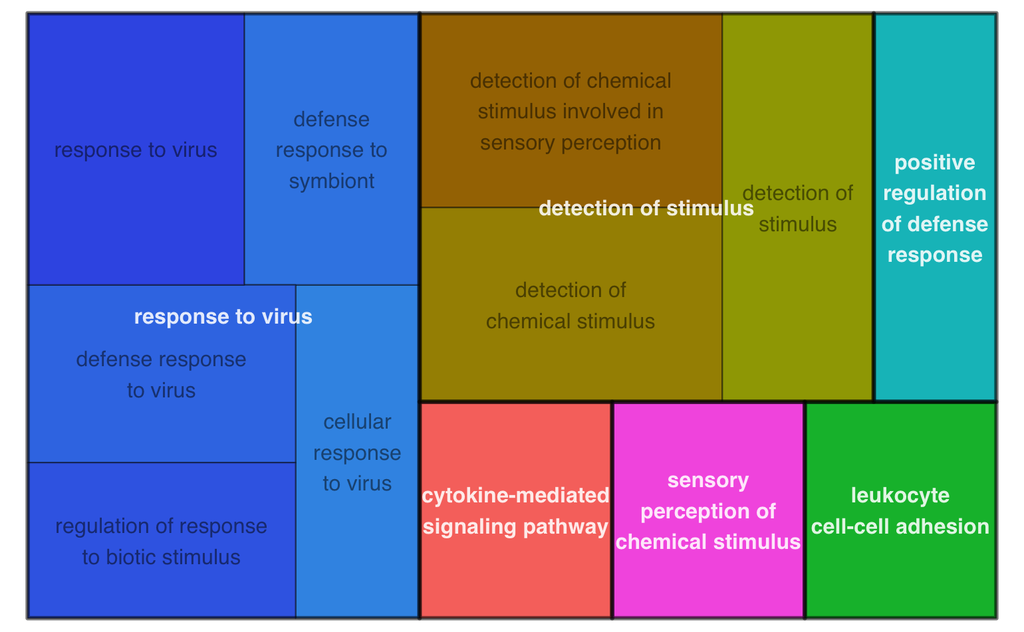

```r
if (nrow(reducedTerms) > 2) {
  treemapPlot(reducedTerms)
}
```

#### Downregulated pathways

There were no downregulated pathways with a padj < 0.15. The smallest padj value for a downregulated pathway was 0.33 (cellular response to zinc ion). The second smallest padj value for a downregulated pathway was 0.48.

```r
gsea_res_df_short2.down <- subset(gsea_res_df_short2, gsea_res_df_short2$NES <= 0)
path = paste0(deseq_output_folder,
              "/IC50_cisplatin_resistant_significantly_downregulated_pathways.csv")
write.csv(gsea_res_df_short2.down, file = path)
gsea_res_df_short2.down
```

| pvalue | p.adjust | NES | Description | core_enrichment_genes |
| --- | --- | --- | --- | --- |